# scNMT_multiomics Help

Aaron Doe

11/21/2019

## Help Page

### Setting up Snakemake

Setting up this pipeline is simpler than setting up the other two. For this pipeline, just ensure that the working directory is located in the same directory as the other two working directories.

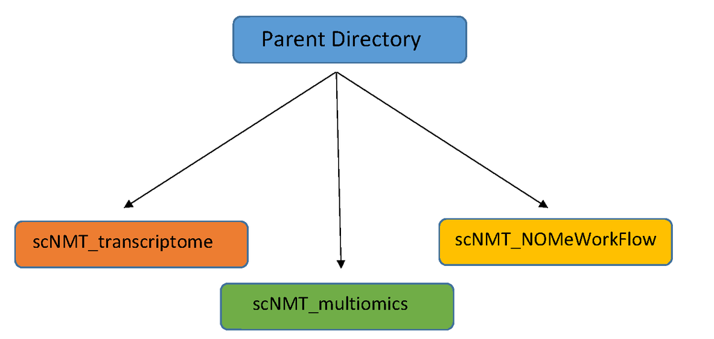

Directory Graph

Once everything is in the right place run a dry run to make sure that all the rules will be run.

```bash
snakemake -np --verbose
```

The rules will grab the necessary files from the transcriptome and NOMe directories.

One thing to look out for that could cause errors are the naming conventions in the transcriptome data versus the NOMe data. If your cells are named slightly differently in the two datasets, they won’t be able to match up and you might have to rename one set so the names match.

### Correlations

#### Correlate_met/acc

This step correlates methylation and accessibility separately with the transcriptome data. Like the correlations in the in the NOMeWorkFlow, this runs weighted Pearson correlations across the sites of the desired genomic annotations. The plots also tell the significance of the correlation along the y-axis and includes a significance cutoff line.

#### Compare Correlation

This is the first step that uses the methylation, chromatin accessibility, and transcriptome information all together. It outputs two plots, one just compares the two correlations created in the last step. This allows the user to easily see if the RNA correlates better with accessibility or methylation for a given site. The next plot is a scatter plot with the accessibility/RNA correlation on the y-axes and the methylation/RNA correlation on the x axis for each site. It also identifies by color the sites that are significant for both of these correlations.

### Differential

#### Get Groups

The first step when doing this differential analysis is to split up the dataset into groups to do the differential analysis across. To do this we grab the clusters that Seurat created from the transcriptome information and assign each cell to a group corresponding to which cluster it belongs to. These groups are then used throughout the rest of the differential analysis

#### Differential Accessibility/Methylation

Now that the groups are established we look across the groups for differential methylation or accessibility. This is done very similar to the way differential expression is done. We average the methylation and accessibility per site across all of the cells in each group, and then compare those averages against group. All of the comparisons we run are 1 to 1 comparisons, so if you have more than 2 groups, it will do 1 to 1 comparisons across all groups iteratively.

#### Plot Differential

This step creates plots based off of all the differential results from the last step. The first set of plots it outputs are volcano plots for both the differential accessibility and the differential methylation. It also outputs a venn diagram showing which sites that are determined to have differential accessibility and methylation overlap with each other and overlap with the corresponding differentially expressed genes in the trascriptome. It also plots a scatter plot with the differential methylation score on the x axis and the differential accessibility score on the y axis.

### MOFA

#### Load Data

The first step in initiating MOFA is loading in all the of the data properly. Here we load in all three datasets and do necessary filtering. We also then select for highly variable genes and sites, as we don’t care about sites with low variability and they slow down/disrupt the training of the model. It then outputs a list of matrices, one being the RNA counts matrix and the rest being matrices containing methylation or accessibility information about each genomic annotation.

#### Run Model

This is the step where the model is trained. You feed in the list of matrices and determine whether you want the data scaled and how many factors you want to use to describe the variance in the data. Raising the number of factors will increase how well the model represents your dataset, but it will also make the output more convoluded and difficult to interpret, so finding a good balance is important. This outputs the trained model in the form of an HDF5 file.

#### Analyze Model

This step takes as input the list of matrices and the trained model. It then outputs a number of plots used to interpret the model. The first plots it outputs tell which latent factors describe what pieces of variance in the dataset. You can use this to see if the model explains the full variance of the dataset as well as will show the user if there are instances of shared variance across datasets.

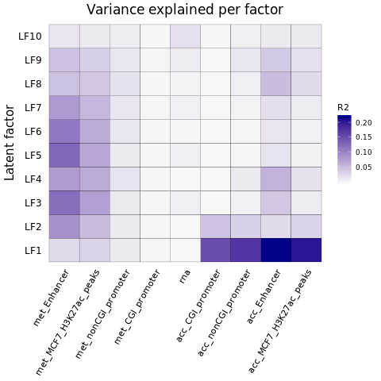

Example Factor Variance Plot

It then outputs a series of plots which allow you to go deeper into each latent factor. One series of plots outputs the driver genes in each latent factor. In this case it is what is driving the RNA component of each latent factor. The code can be edited to print the driving elements for a different component of each latent factor. The other series of plots is similar in that it plots the driving elements of a factor, but this time does it as a heatmap which shows the same information but this time at a single cell resolution to show which cells are being driven by each driving factor. The final output is a UMAP that MOFA creates using all three of the omics together. You can then define how many clusters you want MOFA to find and it will present those on the UMAP. This gives the user a way to define heterogeneity using all three omics.